# Process Simulation Outputs

Author

NAMLink

# Set up

```r
rm(list = ls())

library(tidyverse)
library(data.table)   # fast I/O (fread) and fast grouped operations
library(scales)
library(knitr)
library(openxlsx)
library(kableExtra)

# Helper functions -------------------------------------------------------------
# Keep all local helpers here so this script is stand-alone and does not depend
# on 00_functions.R.

normalize_species <- function(x) {
  dplyr::case_when(
    tolower(x) == "human" ~ "Human",
    tolower(x) %in% c("nhp", "monkey", "primate") ~ "Monkey",
    tolower(x) == "rat" ~ "Rat",
    tolower(x) == "mouse" ~ "Mouse",
    tolower(x) == "dog" ~ "Dog",
    TRUE ~ stringr::str_to_title(x)
  )
}

parse_scenario <- function(path) {
  base  <- tools::file_path_sans_ext(basename(path))
  base  <- sub("_mpk$", "", base)
  parts <- strsplit(base, "_")[[1]]
  n     <- length(parts)

  list(
    Molecule = paste(parts[seq_len(n - 2)], collapse = "_"),
    Species  = parts[n - 1],
    Dose     = suppressWarnings(as.numeric(parts[n]))
  )
}

trapz_auc <- function(time, conc, t_end = Inf) {
  keep <- !is.na(time) & !is.na(conc) & conc > 0 & time <= t_end
  t <- time[keep]
  c <- conc[keep]
  if (length(t) < 2) return(NA_real_)

  dt <- diff(t)
  c1 <- c[-length(c)]
  c2 <- c[-1]

  # Use log trapezoid on strictly declining segments; linear elsewhere.
  use_log <- c1 != c2 & c1 > 0 & c2 > 0
  trap <- ifelse(
    use_log,
    dt * (c1 - c2) / log(c1 / c2),
    dt * (c1 + c2) / 2
  )

  sum(trap)
}

mean_or_na <- function(x) {
  x <- x[is.finite(x)]
  if (length(x) == 0) NA_real_ else mean(x)
}

best_terminal_lambda_z <- function(time_h, conc, min_points = 3L) {
  terminal_data <- tibble(time_h = as.numeric(time_h), conc = as.numeric(conc)) %>%
    filter(is.finite(time_h), is.finite(conc), conc > 0) %>%
    group_by(time_h) %>%
    summarise(conc = mean(conc), .groups = "drop") %>%
    arrange(time_h)

  if (nrow(terminal_data) < min_points) return(NA_real_)

  tmax_index <- which.max(terminal_data$conc)[1]
  post_cmax <- terminal_data %>% slice((tmax_index + 1L):n())
  if (nrow(post_cmax) < min_points) post_cmax <- terminal_data %>% slice(tmax_index:n())
  if (nrow(post_cmax) < min_points) return(NA_real_)

  x <- post_cmax$time_h
  y <- log(post_cmax$conc)
  total_n <- length(x)
  suffix_sum <- function(z) rev(cumsum(rev(z)))
  sx <- suffix_sum(x)
  sy <- suffix_sum(y)
  sxx <- suffix_sum(x * x)
  syy <- suffix_sum(y * y)
  sxy <- suffix_sum(x * y)
  terminal_n <- seq.int(min_points, total_n)
  start_index <- total_n - terminal_n + 1L
  s_xx <- sxx[start_index] - sx[start_index]^2 / terminal_n
  s_yy <- syy[start_index] - sy[start_index]^2 / terminal_n
  s_xy <- sxy[start_index] - sx[start_index] * sy[start_index] / terminal_n
  slope <- s_xy / s_xx
  r2 <- pmin(pmax((s_xy^2) / (s_xx * s_yy), 0), 1)
  adj_r2 <- 1 - (1 - r2) * (terminal_n - 1) / (terminal_n - 2)

  candidates <- tibble(slope, adj_r2, terminal_n) %>%
    filter(is.finite(slope), slope < 0, is.finite(adj_r2)) %>%
    arrange(desc(adj_r2), desc(terminal_n))

  if (nrow(candidates) == 0) NA_real_ else -candidates$slope[1]
}

auc_inf_ug_h_ml <- function(time_h, conc, lambda_z) {
  profile <- tibble(time_h = as.numeric(time_h), conc = as.numeric(conc)) %>%
    filter(
      is.finite(time_h), is.finite(conc),
      time_h >= 0, time_h <= AUC_END_H, conc >= 0
    ) %>%
    group_by(time_h) %>%
    summarise(conc = mean(conc), .groups = "drop") %>%
    arrange(time_h)

  if (nrow(profile) == 0 || !any(profile$conc > 0) || !is.finite(lambda_z)) {
    return(NA_real_)
  }
  if (!any(profile$time_h == 0)) {
    profile <- bind_rows(tibble(time_h = 0, conc = 0), profile) %>% arrange(time_h)
  }

  positive <- profile %>% filter(conc > 0)
  last_index <- which.max(positive$time_h)
  c_last <- positive$conc[last_index]
  last_time <- positive$time_h[last_index]
  through_last <- profile %>% filter(time_h <= last_time)
  dt <- diff(through_last$time_h)
  c1 <- through_last$conc[-nrow(through_last)]
  c2 <- through_last$conc[-1]
  declining <- c2 < c1 & c1 > 0 & c2 > 0
  auc_last <- sum(ifelse(
    declining,
    dt * (c1 - c2) / log(c1 / c2),
    dt * (c1 + c2) / 2
  ))
  auc_last + c_last / lambda_z
}

terminal_clearance_l_day <- function(dose_mg_kg, body_weight_kg, auc_inf) {
  if (
    !is.finite(dose_mg_kg) || dose_mg_kg <= 0 ||
    !is.finite(body_weight_kg) || body_weight_kg <= 0 ||
    !is.finite(auc_inf) || auc_inf <= 0
  ) return(NA_real_)

  # ug*h/mL is numerically mg*h/L; multiplying mg/kg by kg gives whole-body mg.
  24 * dose_mg_kg * body_weight_kg / auc_inf
}

evaluate_profile_timepoints <- function(time_h, conc) {
  profile <- tibble(time_h = as.numeric(time_h), conc = as.numeric(conc)) %>%
    filter(is.finite(time_h), is.finite(conc), time_h >= 0, conc >= 0) %>%
    group_by(time_h) %>%
    summarise(conc = mean(conc), .groups = "drop") %>%
    arrange(time_h)

  if (nrow(profile) == 0) {
    return(tibble(Eval_Time_h = PROFILE_TIMEPOINTS_H, Eval_Conc_ug_mL = NA_real_))
  }
  if (!any(profile$time_h == 0)) {
    profile <- bind_rows(tibble(time_h = 0, conc = 0), profile) %>% arrange(time_h)
  }

  interpolate_one <- function(target_h) {
    exact <- which(abs(profile$time_h - target_h) < 1e-10)
    if (length(exact) > 0) return(profile$conc[exact[1]])
    if (target_h < min(profile$time_h) || target_h > max(profile$time_h)) return(NA_real_)

    lower <- max(which(profile$time_h < target_h))
    upper <- min(which(profile$time_h > target_h))
    t1 <- profile$time_h[lower]
    t2 <- profile$time_h[upper]
    c1 <- profile$conc[lower]
    c2 <- profile$conc[upper]
    fraction <- (target_h - t1) / (t2 - t1)

    if (c1 > 0 && c2 > 0) {
      exp(log(c1) + fraction * (log(c2) - log(c1)))
    } else {
      c1 + fraction * (c2 - c1)
    }
  }

  tibble(
    Eval_Time_h = PROFILE_TIMEPOINTS_H,
    Eval_Conc_ug_mL = map_dbl(PROFILE_TIMEPOINTS_H, interpolate_one)
  )
}

fmt_fe <- function(x) {
  cell_spec(
    ifelse(is.finite(x), formatC(x, format = "f", digits = 2), ""),
    background = ifelse(!is.finite(x), "#FFFFFF", ifelse(x >= 0.5 & x <= 2.0, "#d4edda", "#f8d7da")),
    color      = ifelse(!is.finite(x), "#000000", ifelse(x >= 0.5 & x <= 2.0, "#155724", "#721c24")),
    bold       = TRUE
  )
}

render_metrics_kbl <- function(df, caption) {
  df_fmt <- df %>%
    mutate(
      `Obs Cmax (µg/mL)`   = round(Obs_Cmax, 1),
      `Pred Cmax (µg/mL)`  = round(Pred_Cmax, 1),
      `FE Cmax`            = map_chr(FE_Cmax, fmt_fe),
      `Obs AUC (µg·h/mL)`  = round(Obs_AUC,  0),
      `Pred AUC (µg·h/mL)` = round(Pred_AUC, 0),
      `FE AUC`             = map_chr(FE_AUC,  fmt_fe)
    ) %>%
    select(
      Molecule, `Dose (mg/kg)` = Dose,
      `Obs Cmax (µg/mL)`, `Pred Cmax (µg/mL)`, `FE Cmax`,
      `Obs AUC (µg·h/mL)`, `Pred AUC (µg·h/mL)`, `FE AUC`
    )

  df_fmt %>%
    kbl(
      escape  = FALSE,
      align   = c("l", "r", "r", "r", "c", "r", "r", "c"),
      caption = caption
    ) %>%
    kable_styling(
      bootstrap_options = c("striped", "hover", "condensed"),
      full_width = FALSE,
      font_size  = 13
    ) %>%
    column_spec(5, width = "5em") %>%
    column_spec(8, width = "5em") %>%
    pack_rows(index = setNames(
      rle(df$Molecule)$lengths,
      rle(df$Molecule)$values
    ))
}

read_target_lookup <- function(files) {
  read_one_sheet <- function(file, sheet) {
    x <- openxlsx::read.xlsx(file, sheet = sheet, check.names = FALSE)
    names(x) <- trimws(names(x))
    names_norm <- names(x) %>%
      tolower() %>%
      gsub("[^a-z0-9]+", " ", .) %>%
      trimws()

    molecule_col <- names(x)[match("drug name", names_norm)]
    target_col   <- names(x)[match("target name", names_norm)]

    if (is.na(molecule_col) || is.na(target_col)) {
      return(NULL)
    }

    x %>%
      transmute(
        Molecule = trimws(as.character(.data[[molecule_col]])),
        Target   = trimws(as.character(.data[[target_col]]))
      ) %>%
      filter(
        !is.na(Molecule), Molecule != "",
        !is.na(Target), Target != ""
      ) %>%
      distinct(Molecule, Target)
  }

  purrr::map_dfr(files, function(file) {
    purrr::map_dfr(openxlsx::getSheetNames(file), function(sheet) {
      read_one_sheet(file, sheet)
    })
  }) %>%
    distinct(Molecule, .keep_all = TRUE)
}

add_target <- function(df, lookup = target_lookup) {
  df %>%
    left_join(lookup, by = "Molecule") %>%
    mutate(Target = coalesce(Target, "Target not specified"))
}

render_metrics_kbl <- function(df, caption) {
  df_fmt <- df %>%
    arrange(Target, Molecule, Dose) %>%
    mutate(
      Target_display       = if_else(!duplicated(Target), Target, ""),
      Molecule_display     = if_else(!duplicated(paste(Target, Molecule)), Molecule, ""),
      `Generic BW (kg)`    = round(BW_kg, 1),
      `Obs Cmax (ug/mL)`   = round(Obs_Cmax, 1),
      `Pred Cmax (ug/mL)`  = round(Pred_Cmax, 1),
      `FE Cmax`            = map_chr(FE_Cmax, fmt_fe),
      `Obs AUC0-28d (ug*h/mL)`  = round(Obs_AUC,  0),
      `Pred AUC0-28d (ug*h/mL)` = round(Pred_AUC, 0),
      `FE AUC0-28d`             = map_chr(FE_AUC,  fmt_fe),
      `Obs AUCinf (ug*h/mL)` = round(Obs_AUCinf, 0),
      `Pred AUCinf (ug*h/mL)` = round(Pred_AUCinf, 0),
      `FE AUCinf` = map_chr(FE_AUCinf, fmt_fe),
      `Obs terminal CL (L/day)` = round(Obs_CL_L_day, 3),
      `Pred terminal CL (L/day)` = round(Pred_CL_L_day, 3),
      `FE terminal CL` = map_chr(FE_CL, fmt_fe),
      `Obs mean profile conc (ug/mL)` = round(Obs_mean_profile_conc, 2),
      `Pred mean profile conc (ug/mL)` = round(Pred_mean_profile_conc, 2),
      `Mean pointwise FE` = map_chr(Mean_pointwise_FE, fmt_fe),
      `GOF timepoints (n)` = GOF_timepoints_n
    ) %>%
    select(
      Target = Target_display, Molecule = Molecule_display, `Dose (mg/kg)` = Dose,
      `Generic BW (kg)`,
      `Obs Cmax (ug/mL)`, `Pred Cmax (ug/mL)`, `FE Cmax`,
      `Obs AUC0-28d (ug*h/mL)`, `Pred AUC0-28d (ug*h/mL)`, `FE AUC0-28d`,
      `Obs AUCinf (ug*h/mL)`, `Pred AUCinf (ug*h/mL)`, `FE AUCinf`,
      `Obs terminal CL (L/day)`, `Pred terminal CL (L/day)`, `FE terminal CL`,
      `Obs mean profile conc (ug/mL)`, `Pred mean profile conc (ug/mL)`,
      `Mean pointwise FE`, `GOF timepoints (n)`
    )

  df_fmt %>%
    kbl(
      escape  = FALSE,
      align   = c("l", "l", "r", "r", "r", "r", "c", "r", "r", "c", "r", "r", "c", "r", "r", "c", "r", "r", "c", "r"),
      caption = caption
    ) %>%
    kable_styling(
      bootstrap_options = c("striped", "hover", "condensed"),
      full_width = FALSE,
      font_size  = 13
    ) %>%
    column_spec(7, width = "5em") %>%
    column_spec(10, width = "5em") %>%
    column_spec(13, width = "5em") %>%
    column_spec(16, width = "5em") %>%
    column_spec(19, width = "5em")
}

datadir  <- "../../01_Data/"
results_dir <- "../SimsOutputs/SimulationResults/"
figures_dir <- "../SimsOutputs/Figures"

# AUC integration window: 28 days in hours
AUC_END_H <- 28 * 24   # 672 h
PROFILE_TIMEPOINTS_H <- c(0, 0.25, 1, 2, 4, 6, 12, 24, 48, 96, 168, 336, 504)

# Generic species body weights used for all whole-animal clearance calculations.
# Individual/subject-specific weights are intentionally not used.
SPECIES_BW_KG <- c(Monkey = 3.5, Human = 70)

target_lookup <- read_target_lookup(c(
  file.path(datadir, "Monkey", "Parameters.xlsx"),
  file.path(datadir, "Human", "Parameters_human.xlsx")
))
```

# Load data

## Observed data

```r
obs_raw <- read.csv(
  file.path(datadir, "Monkey", "mAb_data_clean.csv"),
  stringsAsFactors = FALSE,
  check.names      = FALSE
)

# Normalise species labels to match simulation scenario naming convention,
# convert time to hours, and keep only quantifiable rows
obs <- obs_raw %>%
  mutate(
    Species   = normalize_species(Species),
    Time_h    = case_when(
      tolower(trimws(Time.unit)) %in% c("h", "hr", "hour", "hours") ~ as.numeric(Time),
      TRUE ~ as.numeric(Time) / 60
    ),
    Conc_ugmL = as.numeric(Measurement)   # already in µg/mL
  ) %>%
  filter(!is.na(Conc_ugmL), Conc_ugmL > 0) %>%
  filter(Time_h <= 672)

# ── Human observed data (kept separate — not combined with monkey) ────────
obs_human_raw <- read.csv(
  file.path(datadir, "Human", "mAb_data_human.csv"),
  stringsAsFactors = FALSE, check.names = FALSE
)

obs_human <- obs_human_raw %>%
  mutate(
    Species   = normalize_species(Species),
    Time_h    = case_when(
      tolower(trimws(Time.unit)) %in% c("h", "hr", "hour", "hours") ~ as.numeric(Time),
      TRUE ~ as.numeric(Time) / 60
    ),
    Conc_ugmL = as.numeric(Measurement)
  ) %>%
  filter(!is.na(Conc_ugmL), Conc_ugmL > 0) %>%
  # Exclude SC routes — IV model cannot be compared against subcutaneous data
  filter(!grepl("^SC$", trimws(Route), ignore.case = TRUE)) %>%
  filter(Time_h <= AUC_END_H)

# MW lookup: used for unit conversion of simulation output (µmol/L → µg/mL).
# Built from both CSVs so that Golimumab (monkey-only observed) and all human
# drugs are covered.
mw_lookup <- bind_rows(
  obs_raw       %>% distinct(Molecule, MW = Molecular.Weight),
  obs_human_raw %>% distinct(Molecule, MW = Molecular.Weight)
) %>%
  mutate(MW = as.numeric(MW)) %>%
  distinct(Molecule, .keep_all = TRUE)
```

## Simulation results — latest run

```r
# ── Auto-select the most recently modified results sub-folder ─────────────
sim_folders <- list.dirs(results_dir, recursive = FALSE, full.names = TRUE)
if (length(sim_folders) == 0) stop("No results folders found in: ", results_dir)

latest_dir <- sim_folders[which.max(file.mtime(sim_folders))]
message("Results folder: ", latest_dir)

# ── List scenario CSVs (exclude _population parameter files) ──────────────
csv_files <- list.files(latest_dir, pattern = "\\.csv$", full.names = TRUE)
csv_files <- csv_files[!grepl("_population\\.csv$", csv_files)]
message(length(csv_files), " scenario CSV files found")

# ── Read CSVs ─────────────────────────────────────────────────────────────
# Expected columns: IndividualId | Time [min] | {OutputPath} [µmol/l]
# Unit conversion: µmol/L × MW (g/mol) / 1000 = µg/mL

# Function defined outside the loop so it can be exported to parallel workers
read_one_csv <- function(f) {
  meta <- parse_scenario(f)

  df <- tryCatch(
    data.table::fread(f, data.table = TRUE),
    error = function(e) NULL
  )
  if (is.null(df)) return(NULL)

  conc_col <- grep("PeripheralVenousBlood.*Plasma.*\\[", names(df), value = TRUE)
  conc_col <- conc_col[grepl("\\|mAb\\|", conc_col)]
  if (length(conc_col) == 0) return(NULL)
  conc_col <- conc_col[1]

  mw_val <- mw_lookup$MW[mw_lookup$Molecule == meta$Molecule]
  if (length(mw_val) == 0 || is.na(mw_val[1])) return(NULL)

  df[, .(
    Molecule     = meta$Molecule,
    Species      = meta$Species,
    Dose         = meta$Dose,
    IndividualId = as.integer(IndividualId),
    Time_h       = as.numeric(`Time [min]`) / 60,
    Conc_ugmL    = as.numeric(.SD[[conc_col]]) * mw_val[1] / 1000
  ), .SDcols = conc_col[1]]
}

# Parallel CSV reading — uses a socket cluster (works on Windows).
# Falls back to sequential if only 1 logical core is available.
n_cores <- min(length(csv_files), max(1L, parallel::detectCores() - 1L))
message("Reading ", length(csv_files), " scenario CSV(s) with ", n_cores, " core(s)")

if (n_cores > 1) {
  cl <- parallel::makeCluster(n_cores)
  parallel::clusterExport(cl, varlist = c("parse_scenario", "mw_lookup", "read_one_csv"),
                          envir = environment())
  parallel::clusterEvalQ(cl, library(data.table))
  sim_list <- parallel::parLapply(cl, csv_files, read_one_csv)
  parallel::stopCluster(cl)
} else {
  sim_list <- lapply(csv_files, read_one_csv)
}

sim <- data.table::rbindlist(Filter(Negate(is.null), sim_list))

if (nrow(sim) == 0) {
  stop(
    "No concentration data found in any scenario CSV.\n\n",
    "Likely cause: the OutputPath in Scenarios.xlsx references the molecule\n",
    "name (e.g. 'Atezolizumab') but the .pkml model uses a different name internally.\n\n",
    "Fix: update the OutputPaths sheet to use the correct path and re-run 02_Run_Sims.qmd."
  )
}

n_scen <- sim[, .N, by = .(Molecule, Species, Dose)][, .N]
message("Loaded ", n_scen, " scenarios | ",
        uniqueN(sim$IndividualId), " individuals per scenario")
```

# Summarise for plotting

```r
# ── Simulated: 5th / 50th / 95th percentile per time point ────────────────
# data.table grouped operation is 5–20× faster than dplyr on large tables
sim_summary <- sim[, .(
  Pred_p05 = quantile(Conc_ugmL, 0.05, na.rm = TRUE),
  Pred_med = quantile(Conc_ugmL, 0.50, na.rm = TRUE),
  Pred_p95 = quantile(Conc_ugmL, 0.95, na.rm = TRUE)
), by = .(Molecule, Species, Dose, Time_h)]

# ── Observed: mean ± SD per group / time point ────────────────────────────
summarise_obs <- function(df) {
  df %>%
    group_by(Molecule, Species, Dose, Time_h) %>%
    summarise(
      Obs_mean = mean(Conc_ugmL, na.rm = TRUE),
      Obs_sd   = sd(Conc_ugmL,   na.rm = TRUE),
      n        = n(),
      .groups  = "drop"
    ) %>%
    mutate(
      Obs_lo = pmax(Obs_mean - Obs_sd, 1e-4),
      Obs_hi = Obs_mean + Obs_sd
    )
}

obs_summary       <- summarise_obs(obs)
obs_human_summary <- summarise_obs(obs_human)

# Combined only for plotting (both species appear in the same figure per drug)
obs_all_summary <- bind_rows(obs_summary, obs_human_summary)

sim_summary <- sim_summary %>%
  as_tibble() %>%
  add_target() %>%
  arrange(Target, Molecule, Species, Dose, Time_h) %>%
  mutate(
    Molecule = factor(Molecule, levels = unique(Molecule)),
    Facet    = factor(paste(Target, Molecule, sep = " | "),
                      levels = unique(paste(Target, Molecule, sep = " | ")))
  )

obs_all_summary <- obs_all_summary %>%
  add_target() %>%
  arrange(Target, Molecule, Species, Dose, Time_h) %>%
  mutate(
    Molecule = factor(Molecule, levels = levels(sim_summary$Molecule)),
    Facet    = factor(paste(Target, Molecule, sep = " | "),
                      levels = levels(sim_summary$Facet))
  )
```

# PK profiles: observed vs simulated

One figure per species; panels = molecules; colour = dose.

```r
molecules <- character(0)

pk_plots <- lapply(molecules, function(mol) {

  sim_mol <- sim_summary[Molecule == mol]   # data.table subset
  obs_mol <- filter(obs_all_summary, Molecule == mol)

  p <- ggplot() +

    # Prediction uncertainty ribbon (5th–95th percentile)
    geom_ribbon(
      data  = sim_mol,
      aes(x = Time_h, ymin = Pred_p05, ymax = Pred_p95, fill = factor(Dose)),
      alpha = 0.18
    ) +

    # Predicted median line
    geom_line(
      data      = sim_mol,
      aes(x = Time_h, y = Pred_med, colour = factor(Dose)),
      linewidth = 0.9
    ) +

    # Observed mean points
    geom_point(
      data  = obs_mol,
      aes(x = Time_h, y = Obs_mean, colour = factor(Dose)),
      shape = 16, size = 2.3
    ) +

    # Observed ± SD error bars
    geom_errorbar(
      data      = filter(obs_mol, !is.na(Obs_sd) & n > 1),
      aes(x = Time_h, ymin = Obs_lo, ymax = Obs_hi, colour = factor(Dose)),
      width     = 0.8, linewidth = 0.45
    ) +

    facet_wrap(~ Species, scales = "free_x") +
    scale_y_log10(limits = c(0.1, NA),
      labels = label_number(drop0trailing = TRUE),
      breaks = 10^seq(-2, 4)
    ) +
    scale_colour_viridis_d(name = "Dose (mg/kg)", option = "D", end = 0.88) +
    scale_fill_viridis_d(name   = "Dose (mg/kg)", option = "D", end = 0.88) +
    labs(
      title    = mol,
      subtitle = "Lines = simulated |  Points = observed",
      x        = "Time (h)",
      y        = "Plasma Concentration (µg/mL)"
    ) +
    theme_bw(base_size = 12) +
    theme(
      strip.background = element_rect(fill = "grey93"),
      strip.text       = element_text(face = "bold"),
      legend.position  = "bottom",
      panel.grid.minor = element_blank()
    )

  ggsave(
    file.path(figures_dir, paste0("PK_ObsPred_", mol, ".png")),
    p, width = 10, height = 4.5, dpi = 150
  )
  message("Saved plot: ", mol)
  p
})

names(pk_plots) <- molecules
pk_plots
```

```
named list()
```

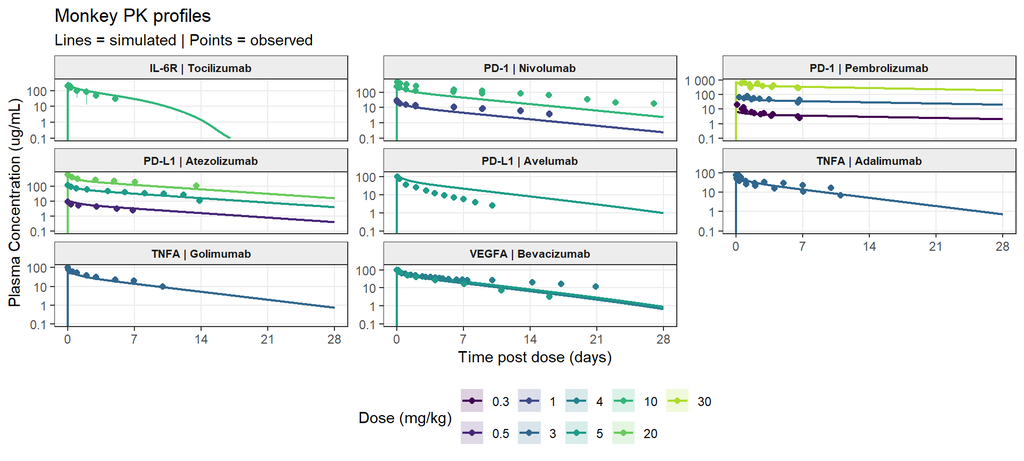

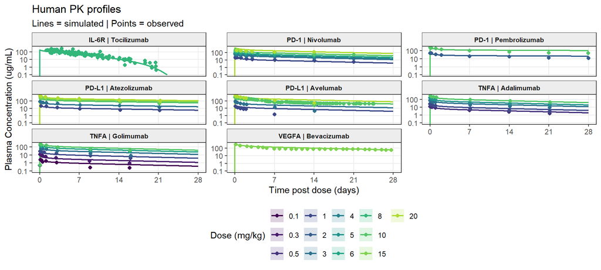

```r
old_pk_plots <- list.files(
  figures_dir,
  pattern = "^PK_ObsPred_.*\\.png$",
  full.names = TRUE
)
old_pk_plots <- old_pk_plots[
  !basename(old_pk_plots) %in% c("PK_ObsPred_Monkey.png", "PK_ObsPred_Human.png")
]
if (length(old_pk_plots) > 0) unlink(old_pk_plots)

plot_species_pk <- function(species_label) {
  sim_species <- sim_summary %>%
    filter(Species == species_label, Time_h <= AUC_END_H)

  obs_species <- obs_all_summary %>%
    filter(Species == species_label, Time_h <= AUC_END_H)

  p <- ggplot() +
    geom_ribbon(
      data  = sim_species,
      aes(x = Time_h, ymin = Pred_p05, ymax = Pred_p95, fill = factor(Dose)),
      alpha = 0.18
    ) +
    geom_line(
      data      = sim_species,
      aes(x = Time_h, y = Pred_med, colour = factor(Dose)),
      linewidth = 0.8
    ) +
    geom_point(
      data  = obs_species,
      aes(x = Time_h, y = Obs_mean, colour = factor(Dose)),
      shape = 16, size = 1.7
    ) +
    geom_errorbar(
      data      = filter(obs_species, !is.na(Obs_sd) & n > 1),
      aes(x = Time_h, ymin = Obs_lo, ymax = Obs_hi, colour = factor(Dose)),
      width     = 0.8, linewidth = 0.35
    ) +
    facet_wrap(~ Facet, scales = "free_y", ncol = 3) +
    scale_x_continuous(
      limits = c(0, AUC_END_H),
      breaks = seq(0, AUC_END_H, by = 168),
      labels = function(x) x / 24
    ) +
    scale_y_log10(
      limits = c(0.1, NA),
      labels = label_number(drop0trailing = TRUE),
      breaks = 10^seq(-2, 4)
    ) +
    scale_colour_viridis_d(name = "Dose (mg/kg)", option = "D", end = 0.88) +
    scale_fill_viridis_d(name   = "Dose (mg/kg)", option = "D", end = 0.88) +
    labs(
      title    = paste(species_label, "PK profiles"),
      subtitle = "Lines = simulated | Points = observed",
      x        = "Time post dose (days)",
      y        = "Plasma Concentration (ug/mL)"
    ) +
    theme_bw(base_size = 11) +
    theme(
      strip.background = element_rect(fill = "grey93"),
      strip.text       = element_text(face = "bold", size = 8),
      legend.position  = "bottom",
      panel.grid.minor = element_blank()
    )

  outfile <- file.path(figures_dir, paste0("PK_ObsPred_", species_label, ".png"))
  ggsave(outfile, p, width = 12, height = 8, dpi = 150)
  message("Saved plot: ", outfile)
  p
}

pk_plots <- list(
  Monkey = plot_species_pk("Monkey"),
  Human  = plot_species_pk("Human")
)
pk_plots
```

# PK metrics: C<sub>max</sub>, AUC<sub>0–28d</sub>, AUC<sub>inf</sub>, clearance, and profile goodness of fit

AUC is integrated by the linear-log trapezoidal rule over 0 – 672 h (28 days). For observed subjects the integral is truncated at their last measured time point when that falls before 672 h. The terminal phase is selected from consecutive post-Cmax suffixes using the largest adjusted R-squared. Terminal clearance uses `AUCinf = AUClast + Clast/lambda_z` and `24 * Dose (mg/kg) * generic species BW (kg) / AUCinf`. Clearance is reported in L/day per whole animal/human. Generic BW is 3.5 kg for monkey and 70 kg for human; individual or subject weights are not used. Concentrations are evaluated at 0, 0.25, 1, 2, 4, 6, 12, 24, 48, 96, 168, 336, and 504 h by exact matching or linear-up/log-linear interpolation. The whole-profile goodness of fit is the arithmetic mean of the predicted/observed fold errors at common positive observed timepoints. Fold errors within 0.5–2.0 are highlighted green.

```r
# ── Simulated metrics: fully vectorised — no per-group R function calls ────
# Sort once, then compute lead/lag differences across all groups simultaneously.
# This replaces thousands of trapz_auc() dispatches with three data.table ops.
setorder(sim, Molecule, Species, Dose, IndividualId, Time_h)

sim <- sim %>%
  group_by(Molecule, Species, Dose, IndividualId) %>%
  mutate(
    dt_h = Time_h - lag(Time_h),
    c_lag = lag(Conc_ugmL)
  ) %>%
  ungroup()  %>%
  mutate(
    trap = case_when(
      is.na(dt_h) | dt_h <= 0 |
        is.na(c_lag) | c_lag <= 0 |
        Conc_ugmL <= 0 ~ 0,

      c_lag != Conc_ugmL ~
        dt_h * (c_lag - Conc_ugmL) / log(c_lag / Conc_ugmL),

      TRUE ~
        dt_h * (c_lag + Conc_ugmL) / 2
    ))

sim_metrics <- sim %>%
  filter(Time_h <= AUC_END_H) %>%
  group_by(Molecule, Species, Dose, IndividualId) %>%
  summarise(
    Pred_AUC  = sum(trap, na.rm = TRUE),
    Pred_Cmax = max(Conc_ugmL, na.rm = TRUE),
    BW_kg = unname(SPECIES_BW_KG[Species[1]]),
    Pred_lambda_z_1_h = best_terminal_lambda_z(Time_h, Conc_ugmL),
    Pred_AUCinf = auc_inf_ug_h_ml(Time_h, Conc_ugmL, Pred_lambda_z_1_h),
    Pred_CL_L_day = terminal_clearance_l_day(Dose[1], BW_kg[1], Pred_AUCinf),
    .groups = "drop"
  ) %>%
  group_by(Molecule, Species, Dose) %>%
  summarise(
    Pred_AUC  = mean(Pred_AUC, na.rm = TRUE),
    Pred_Cmax = mean(Pred_Cmax, na.rm = TRUE),
    BW_kg = first(BW_kg),
    Pred_AUCinf = mean_or_na(Pred_AUCinf),
    Pred_CL_L_day = mean_or_na(Pred_CL_L_day),
    .groups = "drop"
  )

sim <- sim %>%
  select(-dt_h, -c_lag, -trap)

# ── Observed metrics helper: per subject → group mean ────────────────────
compute_obs_metrics <- function(df) {
  df %>%
    group_by(Molecule, Species, Dose, Subject.Id) %>%
    summarise(
      Obs_AUC  = trapz_auc(Time_h, Conc_ugmL, t_end = AUC_END_H),
      Obs_Cmax = max(Conc_ugmL, na.rm = TRUE),
      BW_kg = unname(SPECIES_BW_KG[Species[1]]),
      Obs_lambda_z_1_h = best_terminal_lambda_z(Time_h, Conc_ugmL),
      Obs_AUCinf = auc_inf_ug_h_ml(Time_h, Conc_ugmL, Obs_lambda_z_1_h),
      Obs_CL_L_day = terminal_clearance_l_day(Dose[1], BW_kg[1], Obs_AUCinf),
      .groups  = "drop"
    ) %>%
    group_by(Molecule, Species, Dose) %>%
    summarise(
      Obs_Cmax = mean(Obs_Cmax, na.rm = TRUE),
      Obs_AUC  = mean(Obs_AUC,  na.rm = TRUE),
      BW_kg = first(BW_kg),
      Obs_AUCinf = mean_or_na(Obs_AUCinf),
      Obs_CL_L_day = mean_or_na(Obs_CL_L_day),
      .groups  = "drop"
    )
}

obs_metrics       <- compute_obs_metrics(obs)
obs_human_metrics <- compute_obs_metrics(obs_human)

sim_profile_timepoints <- sim %>%
  filter(Time_h <= max(PROFILE_TIMEPOINTS_H)) %>%
  group_by(Molecule, Species, Dose, IndividualId) %>%
  group_modify(~ evaluate_profile_timepoints(.x$Time_h, .x$Conc_ugmL)) %>%
  ungroup() %>%
  group_by(Molecule, Species, Dose, Eval_Time_h) %>%
  summarise(Pred_Eval_Conc = mean_or_na(Eval_Conc_ug_mL), .groups = "drop")

compute_obs_profile_timepoints <- function(df) {
  df %>%
    filter(Time_h <= max(PROFILE_TIMEPOINTS_H)) %>%
    group_by(Molecule, Species, Dose, Subject.Id) %>%
    group_modify(~ evaluate_profile_timepoints(.x$Time_h, .x$Conc_ugmL)) %>%
    ungroup() %>%
    group_by(Molecule, Species, Dose, Eval_Time_h) %>%
    summarise(Obs_Eval_Conc = mean_or_na(Eval_Conc_ug_mL), .groups = "drop")
}

obs_profile_timepoints <- bind_rows(
  compute_obs_profile_timepoints(obs),
  compute_obs_profile_timepoints(obs_human)
)

profile_gof <- full_join(
  obs_profile_timepoints,
  sim_profile_timepoints,
  by = c("Molecule", "Species", "Dose", "Eval_Time_h")
) %>%
  group_by(Molecule, Species, Dose) %>%
  summarise(
    Obs_mean_profile_conc = mean_or_na(Obs_Eval_Conc),
    Pred_mean_profile_conc = mean_or_na(Pred_Eval_Conc),
    GOF_timepoints_n = sum(
      is.finite(Obs_Eval_Conc) & Obs_Eval_Conc > 0 & is.finite(Pred_Eval_Conc)
    ),
    Mean_pointwise_FE = mean_or_na(if_else(
      is.finite(Obs_Eval_Conc) & Obs_Eval_Conc > 0 & is.finite(Pred_Eval_Conc),
      Pred_Eval_Conc / Obs_Eval_Conc,
      NA_real_
    )),
    .groups = "drop"
  )

compute_fe <- function(obs_m, sim_m) {
  full_join(
    as.data.frame(obs_m),
    as.data.frame(sim_m),
    by = c("Molecule", "Species", "Dose")
  ) %>%
    mutate(
      BW_kg = coalesce(BW_kg.x, BW_kg.y),
      FE_Cmax = round(Pred_Cmax / Obs_Cmax, 2),
      FE_AUC  = round(Pred_AUC  / Obs_AUC,  2),
      FE_AUCinf = round(Pred_AUCinf / Obs_AUCinf, 2),
      FE_CL = round(Pred_CL_L_day / Obs_CL_L_day, 2)
    ) %>%
    select(-BW_kg.x, -BW_kg.y) %>%
    left_join(profile_gof, by = c("Molecule", "Species", "Dose")) %>%
    add_target() %>%
    arrange(Target, Molecule, Dose)
}

# Monkey and human joined separately — no cross-species contamination
sim_metrics_monkey <- sim_metrics %>% filter(Species == "Monkey")
sim_metrics_human  <- sim_metrics %>% filter(Species == "Human")

metrics_tbl       <- compute_fe(obs_metrics,       sim_metrics_monkey)
human_metrics_tbl <- compute_fe(obs_human_metrics, sim_metrics_human)
```

```r
metrics_tbl %>%
  render_metrics_kbl(paste("Monkey PK Metrics — Cmax, AUC0-28d, AUCinf, clearance, and profile goodness of fit;",
                     paste0("AUC integrated over 0–", AUC_END_H, " h (28 days).
                            FE = Predicted / Observed.")
))
```

Monkey PK Metrics Cmax, AUC0-28d, AUCinf, clearance, and profile goodness of fit; AUC integrated over 0672 h (28 days). FE = Predicted / Observed.

| Target | Molecule | Dose (mg/kg) | Generic BW (kg) | Obs Cmax (ug/mL) | Pred Cmax (ug/mL) | FE Cmax | Obs AUC0-28d (ug*h/mL) | Pred AUC0-28d (ug*h/mL) | FE AUC0-28d | Obs AUCinf (ug*h/mL) | Pred AUCinf (ug*h/mL) | FE AUCinf | Obs terminal CL (L/day) | Pred terminal CL (L/day) | FE terminal CL | Obs mean profile conc (ug/mL) | Pred mean profile conc (ug/mL) | Mean pointwise FE | GOF timepoints (n) |
| --- | --- | --- | --- | --- | --- | --- | --- | --- | --- | --- | --- | --- | --- | --- | --- | --- | --- | --- | --- |
| IL-6R | Tocilizumab | 10.0 | 3.5 | 250.4 | 266.6 | 1.06 | 8705 | 15634 | 1.80 | 11723 | 15645 | 1.33 | 0.136 | 0.054 | 0.40 | 116.97 | 124.19 | 1.69 | 9 |
| PD-1 | Nivolumab | 1.0 | 3.5 | 27.0 | 26.3 | 0.97 | 3597 | 2237 | 0.62 | 4578 | 2279 | 0.50 | 0.018 | 0.037 | 2.00 | 14.88 | 12.79 | 0.85 | 11 |
|  |  | 10.0 | 3.5 | 357.3 | 263.0 | 0.74 | 45093 | 21970 | 0.49 | 58328 | 22383 | 0.38 | 0.015 | 0.038 | 2.56 | 191.19 | 126.81 | 0.90 | 11 |
|  | Pembrolizumab | 0.3 | 3.5 | 19.8 | 7.9 | 0.40 | 867 | 2075 | 2.39 | 1258 | 3886 | 3.09 | 0.020 | 0.006 | 0.32 | 8.34 | 4.77 | 1.27 | 9 |
|  |  | 3.0 | 3.5 | 79.9 | 78.9 | 0.99 | 7202 | 20732 | 2.88 | 18069 | 38921 | 2.15 | 0.014 | 0.006 | 0.46 | 34.09 | 47.63 | 6.19 | 9 |
|  |  | 30.0 | 3.5 | 753.2 | 789.2 | 1.05 | 62717 | 202461 | 3.23 | 108681 | 377793 | 3.48 | 0.023 | 0.007 | 0.29 | 273.08 | 471.13 | 11.28 | 9 |
| PD-L1 | Atezolizumab | 0.5 | 3.5 | 9.1 | 13.0 | 1.42 | 680 | 1542 | 2.27 | 1086 | 1637 | 1.51 | 0.039 | 0.026 | 0.66 | 5.59 | 6.70 | 1.52 | 9 |
|  |  | 5.0 | 3.5 | 118.8 | 129.7 | 1.09 | 13896 | 15389 | 1.11 | 16019 | 16347 | 1.02 | 0.026 | 0.026 | 0.98 | 71.23 | 66.83 | 1.17 | 10 |
|  |  | 20.0 | 3.5 | 603.5 | 518.9 | 0.86 | 69258 | 60074 | 0.87 | 101362 | 63878 | 0.63 | 0.017 | 0.026 | 1.59 | 352.78 | 263.90 | 0.90 | 10 |
|  | Avelumab | 5.0 | 3.5 | 102.2 | 132.4 | 1.30 | 3953 | 11060 | 2.80 | 4271 | 11203 | 2.62 | 0.098 | 0.037 | 0.38 | 44.62 | 64.09 | 2.66 | 10 |
| TNFA | Adalimumab | 3.0 | 3.5 | 66.1 | 80.0 | 1.21 | 5544 | 6778 | 1.22 | 7980 | 6905 | 0.87 | 0.035 | 0.036 | 1.05 | 36.76 | 38.83 | 1.33 | 10 |
|  | Golimumab | 3.0 | 3.5 | 100.7 | 81.1 | 0.80 | 6856 | 6870 | 1.00 | 8134 | 6998 | 0.86 | 0.031 | 0.036 | 1.16 | 55.37 | 39.36 | 0.82 | 10 |
| VEGFA | Bevacizumab | 4.0 | 3.5 | 94.9 | 108.1 | 1.14 | 14001 | 8959 | 0.64 | 18043 | 9047 | 0.50 | 0.019 | 0.037 | 1.99 | 44.15 | 52.34 | 2.20 | 11 |
|  |  | 5.0 | 3.5 | 100.0 | 135.1 | 1.35 | 7572 | 11218 | 1.48 | 8027 | 11341 | 1.41 | 0.052 | 0.037 | 0.71 | 51.74 | 65.38 | 1.44 | 11 |

## Human — observed vs predicted PK metrics

```r
if (nrow(human_metrics_tbl) > 0) {
  render_metrics_kbl(
    human_metrics_tbl,
    paste("Human PK Metrics — Cmax, AUC0-28d, AUCinf, clearance, and profile goodness of fit.",
          "FE = Predicted / Observed.")
  )
}
```

Human PK Metrics Cmax, AUC0-28d, AUCinf, clearance, and profile goodness of fit. FE = Predicted / Observed.

| Target | Molecule | Dose (mg/kg) | Generic BW (kg) | Obs Cmax (ug/mL) | Pred Cmax (ug/mL) | FE Cmax | Obs AUC0-28d (ug*h/mL) | Pred AUC0-28d (ug*h/mL) | FE AUC0-28d | Obs AUCinf (ug*h/mL) | Pred AUCinf (ug*h/mL) | FE AUCinf | Obs terminal CL (L/day) | Pred terminal CL (L/day) | FE terminal CL | Obs mean profile conc (ug/mL) | Pred mean profile conc (ug/mL) | Mean pointwise FE | GOF timepoints (n) |
| --- | --- | --- | --- | --- | --- | --- | --- | --- | --- | --- | --- | --- | --- | --- | --- | --- | --- | --- | --- |
| IL-6R | Tocilizumab | 8.0 | 70 | 382.4 | 196.8 | 0.51 | 27439 | 19456 | 0.71 | 25351 | 19465 | 0.77 | 0.530 | 0.690 | 1.30 | 60.51 | 102.52 | 17.21 | 11 |
| PD-1 | Nivolumab | 1.0 | 70 | 24.4 | 24.3 | 1.00 | 4570 | 4984 | 1.09 | 9543 | 7280 | 0.76 | 0.179 | 0.231 | 1.29 | 14.19 | 13.88 | 1.65 | 11 |
|  |  | 3.0 | 70 | 62.4 | 72.8 | 1.17 | 10799 | 14929 | 1.38 | 19855 | 21802 | 1.10 | 0.254 | 0.231 | 0.91 | 31.03 | 41.62 | 2.20 | 12 |
|  |  | 4.0 | 70 | 72.6 | 97.1 | 1.34 | 12774 | 19890 | 1.56 | 23159 | 29045 | 1.25 | 0.290 | 0.231 | 0.80 | 48.70 | 55.48 | 1.71 | 10 |
|  |  | 6.0 | 70 | 113.5 | 145.6 | 1.28 | 18521 | 29787 | 1.61 | 35639 | 43492 | 1.22 | 0.283 | 0.232 | 0.82 | 65.70 | 83.17 | 2.45 | 10 |
|  |  | 10.0 | 70 | 208.0 | 242.7 | 1.17 | 37629 | 49489 | 1.32 | 66096 | 72236 | 1.09 | 0.255 | 0.233 | 0.91 | 112.44 | 138.47 | 1.95 | 12 |
|  |  | 20.0 | 70 | 203.4 | 485.5 | 2.39 | 46431 | 98186 | 2.11 | 157386 | 143210 | 0.91 | 0.213 | 0.235 | 1.10 | 106.24 | 276.19 | 11.57 | 10 |
|  | Pembrolizumab | 2.0 | 70 | 47.0 | 48.5 | 1.03 | 12369 | 15746 | 1.27 | 21273 | 89086 | 4.19 | 0.158 | 0.038 | 0.24 | 31.62 | 30.70 | 1.07 | 11 |
|  |  | 10.0 | 70 | 239.1 | 242.7 | 1.02 | 55743 | 78601 | 1.41 | 86117 | 442363 | 5.14 | 0.195 | 0.038 | 0.19 | 183.98 | 153.44 | 0.93 | 12 |
| PD-L1 | Atezolizumab | 1.0 | 70 | 21.8 | 23.9 | 1.10 | 4361 | 5838 | 1.34 | 6375 | 10807 | 1.70 | 0.264 | 0.155 | 0.59 | 11.38 | 14.19 | 3.24 | 11 |
|  |  | 3.0 | 70 | 86.5 | 71.8 | 0.83 | 15487 | 17510 | 1.13 | 20582 | 32476 | 1.58 | 0.245 | 0.155 | 0.63 | 50.96 | 42.57 | 1.03 | 11 |
|  |  | 10.0 | 70 | 234.5 | 239.4 | 1.02 | 48072 | 58149 | 1.21 | 69997 | 107868 | 1.54 | 0.240 | 0.156 | 0.65 | 128.61 | 141.72 | 2.51 | 11 |
|  |  | 15.0 | 70 | 349.4 | 359.1 | 1.03 | 67350 | 86959 | 1.29 | 97736 | 161208 | 1.65 | 0.258 | 0.156 | 0.61 | 189.45 | 212.36 | 2.10 | 11 |
|  |  | 20.0 | 70 | 559.8 | 478.8 | 0.86 | 100382 | 115585 | 1.15 | 155484 | 214112 | 1.38 | 0.216 | 0.157 | 0.73 | 325.76 | 282.85 | 1.07 | 11 |
|  | Avelumab | 1.0 | 70 | 19.2 | 24.4 | 1.27 | 907 | 5000 | 5.51 | 1046 | 7252 | 6.93 | 1.606 | 0.232 | 0.14 | 7.81 | 13.96 | 3.55 | 10 |
|  |  | 3.0 | 70 | 87.5 | 73.3 | 0.84 | 6101 | 15013 | 2.46 | 6836 | 21873 | 3.20 | 0.737 | 0.230 | 0.31 | 34.13 | 41.89 | 2.29 | 11 |
|  |  | 10.0 | 70 | 268.8 | 244.4 | 0.91 | 33797 | 49809 | 1.47 | 50183 | 72650 | 1.45 | 0.387 | 0.231 | 0.60 | 115.94 | 139.41 | 1.64 | 11 |
|  |  | 20.0 | 70 | 515.6 | 488.8 | 0.95 | 48182 | 98838 | 2.05 | 57345 | 144106 | 2.51 | 0.586 | 0.233 | 0.40 | 230.35 | 278.06 | 2.19 | 11 |
| TNFA | Adalimumab | 0.5 | 70 | 12.5 | 12.3 | 0.98 | 1971 | 2527 | 1.28 | 2638 | 3691 | 1.40 | 0.318 | 0.228 | 0.71 | 9.43 | 7.04 | 0.86 | 11 |
|  |  | 1.0 | 70 | 26.6 | 24.6 | 0.93 | 3357 | 5052 | 1.50 | 4821 | 7379 | 1.53 | 0.348 | 0.228 | 0.65 | 17.57 | 14.07 | 0.97 | 12 |
|  |  | 3.0 | 70 | 72.3 | 73.8 | 1.02 | 10107 | 15133 | 1.50 | 14582 | 22100 | 1.52 | 0.346 | 0.228 | 0.66 | 37.39 | 42.19 | 1.35 | 11 |
|  |  | 5.0 | 70 | 163.0 | 123.0 | 0.75 | 22434 | 25182 | 1.12 | 32654 | 36770 | 1.13 | 0.257 | 0.228 | 0.89 | 86.74 | 70.28 | 0.99 | 11 |
|  |  | 10.0 | 70 | 295.5 | 246.0 | 0.83 | 46446 | 50166 | 1.08 | 68233 | 73222 | 1.07 | 0.246 | 0.229 | 0.93 | 154.19 | 140.37 | 1.34 | 11 |
|  | Golimumab | 0.1 | 70 | 2.6 | 2.5 | 0.95 | 241 | 512 | 2.13 | 282 | 748 | 2.65 | 0.595 | 0.224 | 0.38 | 1.00 | 1.43 | 5.50 | 12 |
|  |  | 0.3 | 70 | 11.9 | 7.5 | 0.63 | 1069 | 1537 | 1.44 | 1265 | 2245 | 1.78 | 0.399 | 0.224 | 0.56 | 5.12 | 4.28 | 7.50 | 12 |
|  |  | 1.0 | 70 | 28.5 | 24.9 | 0.87 | 3916 | 5120 | 1.31 | 4877 | 7479 | 1.53 | 0.344 | 0.225 | 0.65 | 14.29 | 14.26 | 3.09 | 12 |
|  |  | 3.0 | 70 | 63.9 | 74.8 | 1.17 | 8438 | 15338 | 1.82 | 10465 | 22399 | 2.14 | 0.482 | 0.225 | 0.47 | 24.67 | 42.76 | 107.62 | 11 |
|  |  | 6.0 | 70 | 158.8 | 149.6 | 0.94 | 20144 | 30603 | 1.52 | 26446 | 44682 | 1.69 | 0.381 | 0.226 | 0.59 | 61.75 | 85.45 | 207.38 | 11 |
|  |  | 10.0 | 70 | 225.5 | 249.4 | 1.11 | 28523 | 50844 | 1.78 | 41585 | 74212 | 1.78 | 0.404 | 0.226 | 0.56 | 89.53 | 142.27 | 344.49 | 11 |
| VEGFA | Bevacizumab | 15.0 | 70 | 297.2 | 374.0 | 1.26 | 60624 | 75958 | 1.25 | 91027 | 110826 | 1.22 | 0.277 | 0.227 | 0.82 | 152.00 | 213.10 | 2.74 | 11 |

```r
if (nrow(human_metrics_tbl) == 0) message("No human simulation results found.")
```

## Export to Excel

```r
metrics_out <- bind_rows(metrics_tbl, human_metrics_tbl) %>%
  arrange(Species, Target, Molecule, Dose) %>%
  relocate(Species, Target, Molecule, Dose) %>%
  rename(
    `Dose (mg/kg)`       = Dose,
    `Generic BW (kg)`    = BW_kg,
    `Obs Cmax (ug/mL)`   = Obs_Cmax,
    `Pred Cmax (ug/mL)`  = Pred_Cmax,
    `Fold Error Cmax`    = FE_Cmax,
    `Obs AUC0-28d (ug*h/mL)`  = Obs_AUC,
    `Pred AUC0-28d (ug*h/mL)` = Pred_AUC,
    `Fold Error AUC0-28d`     = FE_AUC,
    `Obs AUCinf (ug*h/mL)` = Obs_AUCinf,
    `Pred AUCinf (ug*h/mL)` = Pred_AUCinf,
    `Fold Error AUCinf` = FE_AUCinf,
    `Obs terminal CL (L/day)` = Obs_CL_L_day,
    `Pred terminal CL (L/day)` = Pred_CL_L_day,
    `Fold Error terminal CL` = FE_CL,
    `Obs mean profile conc (ug/mL)` = Obs_mean_profile_conc,
    `Pred mean profile conc (ug/mL)` = Pred_mean_profile_conc,
    `Mean pointwise fold error` = Mean_pointwise_FE,
    `GOF timepoints (n)` = GOF_timepoints_n
  ) %>%
  select(
    Species, Target, Molecule, `Dose (mg/kg)`, `Generic BW (kg)`,
    `Obs Cmax (ug/mL)`, `Pred Cmax (ug/mL)`, `Fold Error Cmax`,
    `Obs AUC0-28d (ug*h/mL)`, `Pred AUC0-28d (ug*h/mL)`, `Fold Error AUC0-28d`,
    `Obs AUCinf (ug*h/mL)`, `Pred AUCinf (ug*h/mL)`, `Fold Error AUCinf`,
    `Obs terminal CL (L/day)`, `Pred terminal CL (L/day)`, `Fold Error terminal CL`,
    `Obs mean profile conc (ug/mL)`, `Pred mean profile conc (ug/mL)`,
    `Mean pointwise fold error`, `GOF timepoints (n)`
  ) %>%
  mutate(across(where(is.numeric), ~ round(.x, 2)))

wb <- createWorkbook()
for (species_label in c("Monkey", "Human")) {
  sheet_name <- paste0(species_label, "_Metrics")
  species_out <- metrics_out %>% filter(Species == species_label)
  addWorksheet(wb, sheet_name)
  writeData(wb, sheet_name, species_out)
  setColWidths(wb, sheet_name, cols = seq_len(ncol(species_out)), widths = "auto")
}

out_xlsx <- file.path(figures_dir, "PK_Metrics_ObsPred.xlsx")
saveWorkbook(wb, out_xlsx, overwrite = TRUE)
message("Saved: ", out_xlsx)
```